# Part II - (FordGoBike Analysis Presentation)

## by Irene Nafula

> For the presentation, I focus on the usage of the service by users according to their gender, user category and age. I start by plotting a pie chart showing the gender distribution of the users followed by introducing a new column called start_hour that extracts the hour of the day when the users use the service. This is an important insight because it could help the service providers know what time of day to do repairs or maintenance for their bikes with affecting their users negatively.

## Dataset Overview

> This data set includes information about individual rides made in a bike-sharing system covering the greater San Francisco Bay area in year 2019 for the month of February

## (Visualization 1)

> The pie char shows that male users constitute 75% while female users constitute 23% and 2% constututes of users who identify as other.

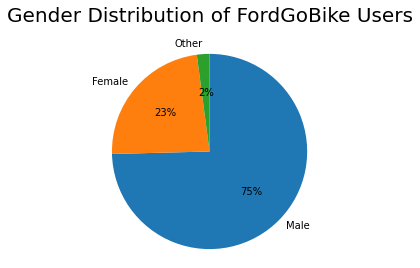

## (Visualization 2)

The most popular hour of the day preferred by both users is in the evening at 1700h.

Subscribers prefer to start their rides at 0800h and 1700h while customers prefer to start their rides at 1700h

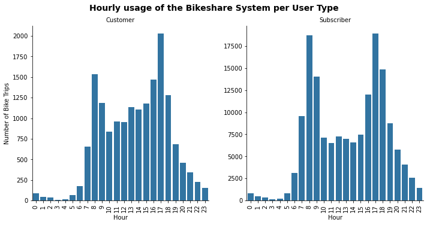

## (Visualization 3)

The analysis below indicates that customers use the service mostly on Thursday, Friday, Sunday, Monday and Tuesday. Subscribers however use the service mostly on weekdays and occasionally on the weekends, that is, Saturday and Sunday.

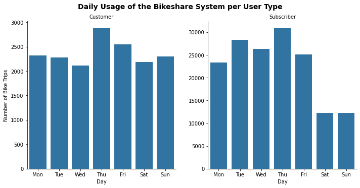

## (Visualization 4)

From the charts below, we can see that male customers prefer to ride on Thursdays and Fridays while female customers prefer to ride on Thursday and Sunday. Customers who identify as other prefer to ride on Thursdays and Fridays while subscribers of the same category prefer to ride on Wednesdays and Thursdays.

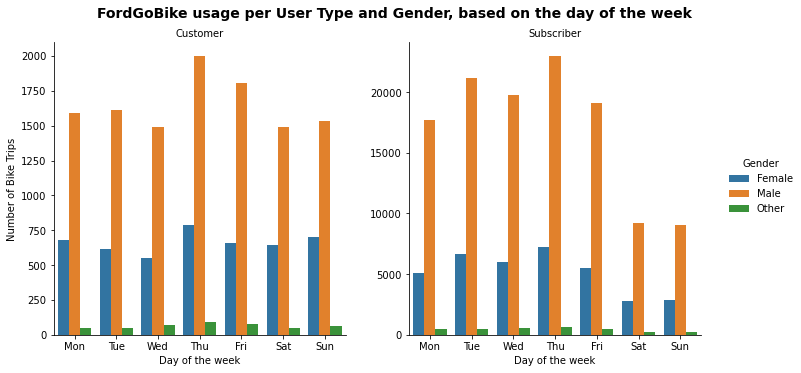

## (Visualization 5)

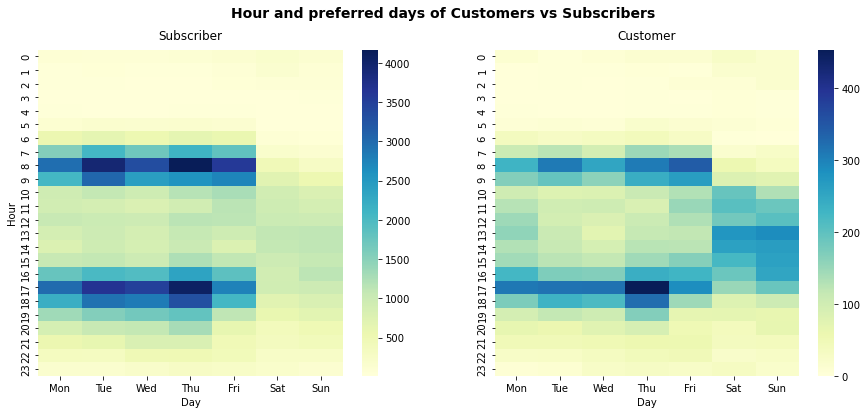